# Models

```r
pacman::p_load(lubridate, dplyr,randomForest, C50, arrow, tidymodels, class,kknn,discrim, tidyverse, purrr, caret, doParallel, pROC)
```

```r
cl <- makePSOCKcluster(4)
registerDoParallel(cl)

train <- read_csv_arrow("data/train.csv")
test <- read_csv_arrow("data/test.csv")
lcd <- read_csv_arrow("data/data2.csv")
```

```r
#factoring categorical variables
train <- train %>%
  filter(!home_ownership %in% c("ANY")) %>%
  mutate(purpose = as.factor(purpose),
         grade = as.factor(grade),
         home_ownership = as.factor(home_ownership),
         loan_status = as.factor(loan_status),
         term = as.factor(term),
         hardship_flag = as.factor(hardship_flag),
         emp_title = as.factor(emp_title),
         emp_length = as.factor(emp_length),
         verification_status = as.factor(verification_status)) %>%
  select(-emp_title, - hardship_flag)

test <- test %>%
  filter(!home_ownership %in% c("ANY")) %>%
  mutate(purpose = as.factor(purpose),
         grade = as.factor(grade),
         home_ownership = as.factor(home_ownership),
         loan_status = as.factor(loan_status),
         term = as.factor(term),
         hardship_flag = as.factor(hardship_flag),
         emp_title = as.factor(emp_title),
         emp_length = as.factor(emp_length),
         verification_status = as.factor(verification_status)) %>%
  select(-emp_title, -hardship_flag)

lcd <- lcd %>%
  filter(!home_ownership %in% c("ANY")) %>%
  mutate(purpose = as.factor(purpose),
         grade = as.factor(grade),
         home_ownership = as.factor(home_ownership),
         loan_status = as.factor(loan_status),
         term = as.factor(term),
         hardship_flag = as.factor(hardship_flag),
         emp_title = as.factor(emp_title),
         emp_length = as.factor(emp_length),
         verification_status = as.factor(verification_status)) %>%
  select(-emp_title, -hardship_flag)

#fixing imbalance in test and training data
test <- test %>%
  filter(!home_ownership %in% "NONE") %>%
  mutate(home_ownership = droplevels(home_ownership))

train <- train %>%
  filter(!home_ownership %in% "OTHER") %>%
  mutate(home_ownership = droplevels(home_ownership))
train <- train %>%
  filter(!purpose %in% "renewable_energy") %>%
  mutate(purpose = droplevels(purpose))
```

# Step 3 - training a model on the data

After training the models, accuracy and kappa statistic were calculated based on models performance in test data set.

## Null Model

```r
mod_null <- logistic_reg(mode = "classification") %>%
  set_engine("glm") %>%
  fit(loan_status ~ 1, data = train)

mod_null %>%
  predict(test)%>%
  bind_cols(test) %>%
  metrics(truth = loan_status, estimate = .pred_class)
```

| .metric | .estimator | .estimate |
| --- | --- | --- |
| accuracy | binary | 0.8388963 |
| kap | binary | 0.0000000 |

## Logistic Regression

```r
mod_log_reg <- logistic_reg(mode= "classification") %>%
  set_engine("glm") %>%
  fit(loan_status~.,  data = train)
```

```r
mod_log_reg %>%
  predict(test)%>%
  bind_cols(test) %>%
  metrics(truth = loan_status, estimate = .pred_class)
```

| .metric | .estimator | .estimate |
| --- | --- | --- |
| accuracy | binary | 0.84067646 |
| kap | binary | 0.05017475 |

## KNN

### Data Preparation

```r
#knn only work for quantitative variable
sample_knn <- train %>%
  select(loan_status, where(is.numeric))
test_knn <- test %>%
  select(loan_status, where(is.numeric))
```

### Knn model

```r
#knn model (with scaling)
mod_knn <- nearest_neighbor(neighbors = 5, mode = "classification") %>%
  set_engine("kknn", scale = TRUE) %>%
  fit(loan_status ~ ., data = sample_knn)

mod_knn
```

```
## parsnip model object
##
##
## Call:
## kknn::train.kknn(formula = loan_status ~ ., data = data, ks = min_rows(5,     data, 5), scale = ~TRUE)
##
## Type of response variable: nominal
## Minimal misclassification: 0.2102762
## Best kernel: optimal
## Best k: 5
```

```r
mod_knn %>%
  predict(test)%>%
  bind_cols(test) %>%
  metrics(truth = loan_status, estimate = .pred_class)
```

| .metric | .estimator | .estimate |
| --- | --- | --- |
| accuracy | binary | 0.79706275 |
| kap | binary | 0.09584167 |

## Decision tree using C50

```r
mod_c50 <- C5.0(train[-9],train$loan_status)

mod_c50
```

```
##
## Call:
## C5.0.default(x = train[-9], y = train$loan_status)
##
## Classification Tree
## Number of samples: 6734
## Number of predictors: 15
##
## Tree size: 1
##
## Non-standard options: attempt to group attributes
```

```r
mod_c50 %>%
  predict(test)%>%
  bind_cols(test) %>%
  metrics(truth = loan_status, estimate = ...1)
```

| .metric | .estimator | .estimate |
| --- | --- | --- |
| accuracy | binary | 0.8388963 |
| kap | binary | 0.0000000 |

## Random Forest

```r
mod_rf <- randomForest(loan_status~., data = train)
```

```r
mod_rf %>%
  predict(test)%>%
  bind_cols(test) %>%
  metrics(truth = loan_status, estimate= ...1)
```

| .metric | .estimator | .estimate |
| --- | --- | --- |
| accuracy | binary | 0.83667112 |
| kap | binary | 0.01027828 |

## Naive Bayes

```r
#train labels
mod_nb <- naive_Bayes(mode = "classification") %>%
  set_engine("klaR") %>%
  fit(loan_status~., data = train)
```

```r
mod_nb %>%
  predict(test)%>%
  bind_cols(test) %>%
  metrics(truth = loan_status, estimate = .pred_class)
```

[output not shown]

# Step 4 - Evaluating Model Performance

## Accuracy Table

```r
prediction_test <- data.frame(
  y = as.character(test$loan_status),
  mod_null = predict(mod_null, test),
  mod_log_reg = predict(mod_log_reg, test),
  mod_rf = predict(mod_rf,test),
  mod_c50 = predict(mod_c50, test),
  mod_nb = predict(mod_nb, test),
  mod_knn = predict(mod_knn,test ))

prediction_test <- prediction_test %>%
  rename(mod_null =.pred_class,
         mod_log_reg = .pred_class.1,
         mod_nb = .pred_class.2,
         mod_knn = .pred_class.3)

prediction_test <- prediction_test %>%
  gather(key = "model", value = "yhat", -y)

accuracy_summary <- prediction_test %>%
  mutate(y = as.factor(y),
         yhat = as.factor(yhat)) %>%
  group_by(model) %>%
  accuracy(truth = y, estimate = yhat) %>%
  arrange(desc(.estimate))

accuracy_summary
```

| model | .metric | .estimator | .estimate |
| --- | --- | --- | --- |
| mod_log_reg | accuracy | binary | 0.8406765 |
| mod_c50 | accuracy | binary | 0.8388963 |
| mod_null | accuracy | binary | 0.8388963 |
| mod_rf | accuracy | binary | 0.8366711 |
| mod_knn | accuracy | binary | 0.7970628 |
| mod_nb | accuracy | binary | 0.7770360 |

*Based on the accuracy metric, log regression is the best model compare to the other models.* However, as the data itself is really imbalance(between defaulted and fully paid ), accuracy shouldn’t be the main focus in judging model performance. Instead, the model comparison will be based on ROC, the trade off between false negative and false positive in identifying loan. Let’s take a look at kappa statistic summary first:

```r
accuracy_summary_kappa <- prediction_test %>%
  mutate(y = as.factor(y),
         yhat = as.factor(yhat)) %>%
  group_by(model) %>%
  kap(truth = y, estimate = yhat) %>%
  arrange(desc(.estimate))

accuracy_summary_kappa
```

| model | .metric | .estimator | .estimate |
| --- | --- | --- | --- |
| mod_nb | kap | binary | 0.16675092 |
| mod_knn | kap | binary | 0.09584167 |
| mod_log_reg | kap | binary | 0.05017475 |
| mod_rf | kap | binary | 0.01027828 |
| mod_c50 | kap | binary | 0.00000000 |
| mod_null | kap | binary | 0.00000000 |

Based on Kappa statistic, naive bayes performed the best, while logistic regression is the third.

## Roc Curve

Now, ROC plot was made to see further performance of the models in classifying loan default, and choose the best model.

```r
default_null <- predict(mod_null, test, type = "prob")
default_log <- predict(mod_log_reg, test, type = "prob")
default_rf <- predict(mod_rf, test, type = "prob")
default_c50 <- data.frame(predict(mod_c50, test, type = "prob"))
default_nb <- predict(mod_nb, test, type = "prob")
default_knn <- predict(mod_knn, test, type = "prob")

default_rf <-as.data.frame(default_rf)

roc_orig_reg <- roc(test$loan_status, predictor = default_log$.pred_Defaulted) #0.6833
roc_orig_null <- roc(test$loan_status, predictor = default_null$.pred_Defaulted) #0.5
roc_orig_c50 <- roc(test$loan_status, predictor = default_c50$Defaulted) #0.4192
roc_orig_knn <- roc(test$loan_status, predictor = default_knn$.pred_Defaulted) #0.6111
roc_orig_rf <- roc(test$loan_status, predictor = default_rf$Defaulted) #0.6727
roc_orig_nb <- roc(test$loan_status, predictor = default_nb$.pred_Defaulted) #0.6876
```

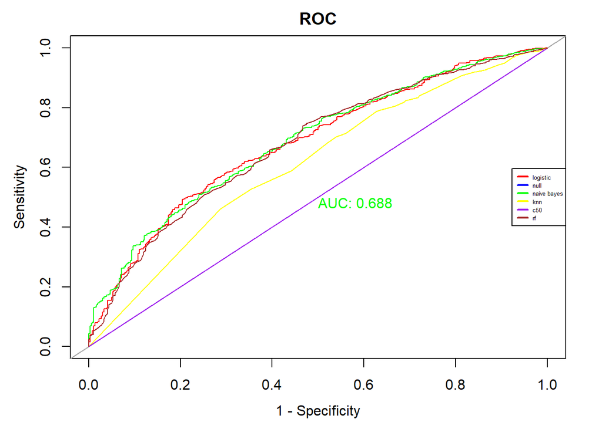

```r
plot(roc_orig_reg, col= "red",lwd = 1,main = "ROC" ,legacy.axes = TRUE, xlim=c(1,0), asp = NA)
plot(roc_orig_null, col= "blue",lwd = 1, add = TRUE)
plot(roc_orig_nb, col= "green",lwd = 1 ,add = TRUE, print.auc = TRUE)
plot(roc_orig_knn, col = "yellow",lwd = 1, add = TRUE)
plot(roc_orig_c50, col = "purple",lwd = 1 ,add = TRUE)
plot(roc_orig_rf, col = "brown",lwd = 1 ,add = TRUE)

legend("right", legend=c("logistic", "null", "naive bayes", "knn", "c50", "rf"), col=c("red", "blue", "green", "yellow", "purple", "brown"), lwd=2, cex =0.4, xpd = TRUE)
```

*Based on AUC, the best model is naive bayes*

# Step 5 - Improving Model

to improve the model, each model’s parameters will be tuned using cross validation method with 5 fold.

```r
#5 fold cross validation
ctrl <- trainControl(method = "cv", number = 5,
selectionFunction = "best", savePredictions = TRUE,
classProbs = TRUE,
summaryFunction = twoClassSummary)

#fixing the levels name in response variable
levels(lcd$loan_status) <- c("defaulted", "fully.paid")

#fixing levels name in knn in response variable
levels(lcd$loan_status) <- c("defaulted", "fully.paid")

levels(lcd$loan_status) <- c("defaulted", "fully.paid")
```

## Logistic Regression

```r
mod_log_tuned<- train(loan_status~., data = lcd, method="glmnet", metric = "ROC", trControl = ctrl)

mod_log_tuned
```

```
## glmnet
##
## 8986 samples
##   15 predictor
##    2 classes: 'defaulted', 'fully.paid'
##
## No pre-processing
## Resampling: Cross-Validated (5 fold)
## Summary of sample sizes: 7188, 7188, 7189, 7189, 7190
## Resampling results across tuning parameters:
##
##   alpha  lambda        ROC        Sens        Spec
##   0.10   0.0001688506  0.6921930  0.01558406  0.9966707
##   0.10   0.0016885059  0.6921341  0.01422813  0.9974700
##   0.10   0.0168850585  0.6931148  0.00677508  0.9992011
##   0.55   0.0001688506  0.6921529  0.01422813  0.9966707
##   0.55   0.0016885059  0.6919947  0.01151397  0.9977362
##   0.55   0.0168850585  0.6932916  0.00000000  1.0000000
##   1.00   0.0001688506  0.6920305  0.01422813  0.9968038
##   1.00   0.0016885059  0.6924626  0.01016033  0.9981356
##   1.00   0.0168850585  0.6885693  0.00000000  1.0000000
##
## ROC was used to select the optimal model using the largest value.
## The final values used for the model were alpha = 0.55 and lambda = 0.01688506.
```

## KNN

```r
sample_tuned_knn <- lcd %>%
  select(loan_status, where(is.numeric))

sample_tuned_knn <- as.data.frame(scale(sample_tuned_knn[2:10]))

sample_tuned_knn <- sample_tuned_knn %>%
  mutate(loan_status = lcd$loan_status)

mod_knn_tuned <- train(loan_status ~ ., data =sample_tuned_knn, method = "knn",metric = "ROC", trControl = ctrl)

mod_knn_tuned
```

```
## k-Nearest Neighbors
##
## 8986 samples
##    9 predictor
##    2 classes: 'defaulted', 'fully.paid'
##
## No pre-processing
## Resampling: Cross-Validated (5 fold)
## Summary of sample sizes: 7188, 7190, 7189, 7189, 7188
## Resampling results across tuning parameters:
##
##   k  ROC        Sens        Spec
##   5  0.6057997  0.09005497  0.9511256
##   7  0.6152440  0.07242556  0.9683047
##   9  0.6169059  0.05957398  0.9770948
##
## ROC was used to select the optimal model using the largest value.
## The final value used for the model was k = 9.
```

## Decision tree C50

```r
mod_c50_tun <- train(loan_status ~ ., data = lcd, method = "C5.0",metric = "ROC", trControl = ctrl)

mod_c50_tun
```

```
## C5.0
##
## 8986 samples
##   15 predictor
##    2 classes: 'defaulted', 'fully.paid'
##
## No pre-processing
## Resampling: Cross-Validated (5 fold)
## Summary of sample sizes: 7189, 7189, 7189, 7188, 7189
## Resampling results across tuning parameters:
##
##   model  winnow  trials  ROC  Sens  Spec
##   rules  FALSE    1      0.5  0     1
##   rules  FALSE   10      0.5  0     1
##   rules  FALSE   20      0.5  0     1
##   rules   TRUE    1      0.5  0     1
##   rules   TRUE   10      0.5  0     1
##   rules   TRUE   20      0.5  0     1
##   tree   FALSE    1      0.5  0     1
##   tree   FALSE   10      0.5  0     1
##   tree   FALSE   20      0.5  0     1
##   tree    TRUE    1      0.5  0     1
##   tree    TRUE   10      0.5  0     1
##   tree    TRUE   20      0.5  0     1
##
## ROC was used to select the optimal model using the largest value.
## The final values used for the model were trials = 1, model = rules and winnow
##  = TRUE.
```

## Random Forest

```r
mod_rf_tuned <- train(loan_status ~ ., data = lcd, method = "rf",metric = "ROC", trControl = ctrl)

mod_rf_tuned
```

```
## Random Forest
##
## 8986 samples
##   15 predictor
##    2 classes: 'defaulted', 'fully.paid'
##
## No pre-processing
## Resampling: Cross-Validated (5 fold)
## Summary of sample sizes: 7188, 7189, 7190, 7189, 7188
## Resampling results across tuning parameters:
##
##   mtry  ROC        Sens        Spec
##    2    0.6637085  0.00000000  1.0000000
##   22    0.6688014  0.04129409  0.9870825
##   43    0.6606755  0.04941136  0.9838866
##
## ROC was used to select the optimal model using the largest value.
## The final value used for the model was mtry = 22.
```

## Naive Bayes

```r
train_nb <- lcd %>%
  select(loan_status,grade,home_ownership, where(is.numeric))

#fixing levels in data
train_nb <- train_nb %>% filter(!home_ownership %in% c("NONE", "OTHER")) %>%
  mutate(home_ownership = droplevels(home_ownership))

levels(train_nb$loan_status) <- c("defaulted", "fully.paid")

mod_nb_tun <- train(loan_status ~ ., data = train_nb,method = "nb", metric = "ROC", trControl = ctrl)

mod_nb_tun
```

```
## Naive Bayes
##
## 8985 samples
##   11 predictor
##    2 classes: 'defaulted', 'fully.paid'
##
## No pre-processing
## Resampling: Cross-Validated (5 fold)
## Summary of sample sizes: 7188, 7188, 7188, 7188, 7188
## Resampling results across tuning parameters:
##
##   usekernel  ROC        Sens          Spec
##   FALSE      0.6694944  0.3021323866  0.8694887
##    TRUE      0.6715952  0.0006779661  0.9989348
##
## Tuning parameter 'fL' was held constant at a value of 0
## Tuning
##  parameter 'adjust' was held constant at a value of 1
## ROC was used to select the optimal model using the largest value.
## The final values used for the model were fL = 0, usekernel = TRUE and adjust
##  = 1.
```

## ROC curve

```r
roc_nb <- roc(mod_nb_tun$pred$obs, mod_nb_tun$pred$defaulted)
roc_rf <- roc(mod_rf_tuned$pred$obs, mod_rf_tuned$pred$defaulted)
roc_log <- roc(mod_log_tuned$pred$obs, mod_log_tuned$pred$defaulted) #0.6929
roc_knn <- roc(mod_knn_tuned$pred$obs, mod_knn_tuned$pred$defaulted)
roc_c50 <- roc(mod_c50_tun$pred$obs, mod_c50_tun$pred$defaulted)
```

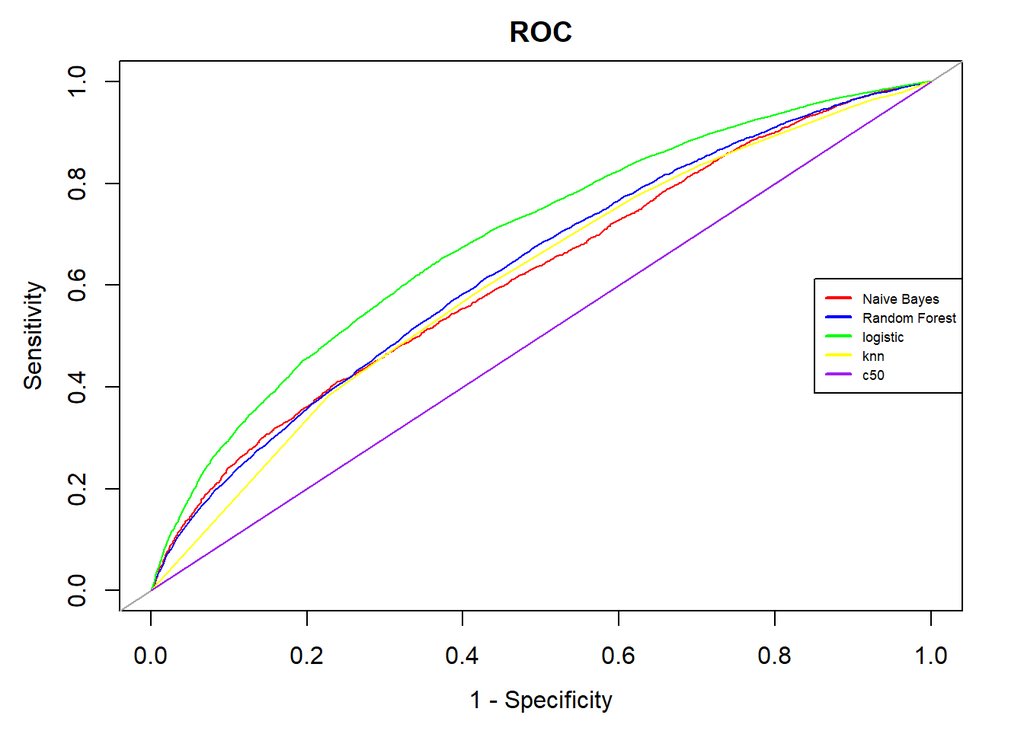

```r
plot(roc_nb, col= "red", lwd = 1,main = "ROC" ,legacy.axes = TRUE, asp = NA)
plot(roc_rf, col= "blue",lwd = 1, add = TRUE)
plot(roc_log, col= "green",lwd = 1 , add = TRUE)
plot(roc_knn, col = "yellow",lwd = 1, add = TRUE)
plot(roc_c50, col = "purple",lwd = 1, add = TRUE)

legend("right", legend=c("Naive Bayes", "Random Forest", "logistic", "knn", "c50"), col=c("red", "blue", "green", "yellow", "purple"), lwd=2, cex =0.55, xpd = TRUE)
```

After tuning the parameter by cross validation in 2012-2014 dataset, logistic regression otperform the other models, with AUC: 0.692.

# Conclusion

Based on the result above,the best model to classify loan default is *logistic regression*. As mentioned before, the best model was picked using AUC metric due to imbalance data in response variable. Furthermore, there are a lot of aspect that can be touched up to improve models performance, one of them is choosing and combining other predictors.